# Load and visualize data from a variety of sources

We demonstrate here how to load data from a variety of data sources and visualize them using [`SpacePhysicsMakie.jl`](https://juliaspacephysics.github.io/SpacePhysicsMakie.jl/).

```julia
using CairoMakie, SpacePhysicsMakie
```

## Get data with `CDAWeb`

CDAWeb.jl provides direct access to NASA’s CDAWeb RESTful services with local caching and fine-grained control over data retrieval.

It could be installed at REPL via `using Pkg; Pkg.add("CDAWeb")`.

```julia
using CDAWeb
t0 = "2024-01-02"
t1 = "2024-01-03"
# ACE solar wind velocity
data1 = cda"AC_H0_SWE/V_GSE"(t0, t1)
```

```
V_GSE (3 × 1350) dims=? × Epoch [Solar Wind Velocity in GSE coord., 3 components; km/s]
```

### Plot the data

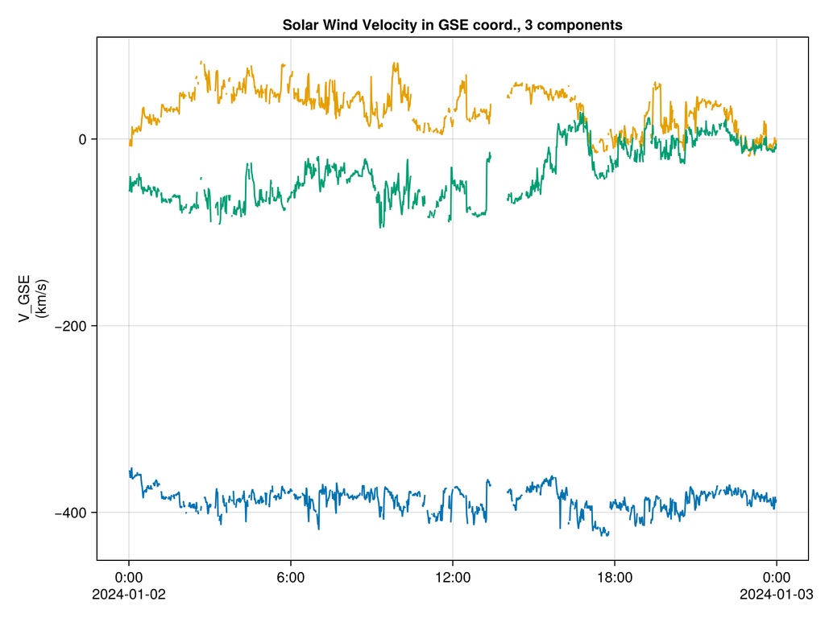

```julia
tplot(data1, add_title=true)
```

## Get data with `Speasy`

Speasy.jl provides functions to load data from main Space Physics WebServices (CDA,SSC,AMDA,..).

It could be installed at REPL via `using Pkg; Pkg.add("Speasy")`.

```julia
import Speasy

data2 = Speasy.get_data("cda/OMNI_HRO_1MIN/Pressure", t0, t1)
```

[output not shown]

```
Speasy.SpeasyVariable{Float32, 2, PythonCall.PyArray{Float32, 2, true, true, Float32}, Tuple{Nothing, Speasy.VariableAxis{Dates.Timestamp{Dates.Nanosecond}, 1, Base.ReinterpretArray{Dates.Timestamp{Dates.Nanosecond}, 1, Int64, PythonCall.PyArray{Int64, 1, true, true, Int64}, false}}}, String, SpaceD…
  Time Range: 2024-01-02T00:00:00 to 2024-01-02T23:59:00
  Units: nPa
  Size: (1, 1440)
  Memory Usage: 18.014 KiB
  Metadata:
    FIELDNAM: Flow pressure
    VALIDMIN: Any[0.0]
    VALIDMAX: Any[100.0]
    SCALEMIN: Any[0.0]
    SCALEMAX: Any[100.0]
    UNITS: nPa
    FORMAT: F5.2
    FILLVAL: Any[99.98999786376953]
    VAR_TYPE: data
    CATDESC: Flow pressure (nPa)
    VAR_NOTES: Derived parameters are obtained from the following equations. Flow pressure = (2*10**-6)*Np*Vp**2 nPa (Np in cm**-3, Vp in km/s, subscript p for proton)
    DISPLAY_TYPE: time_series
    DEPEND_0: Epoch
    LABLAXIS: Flow pressure
    BIN_LOCATION: 0.0
```

### Plot the data

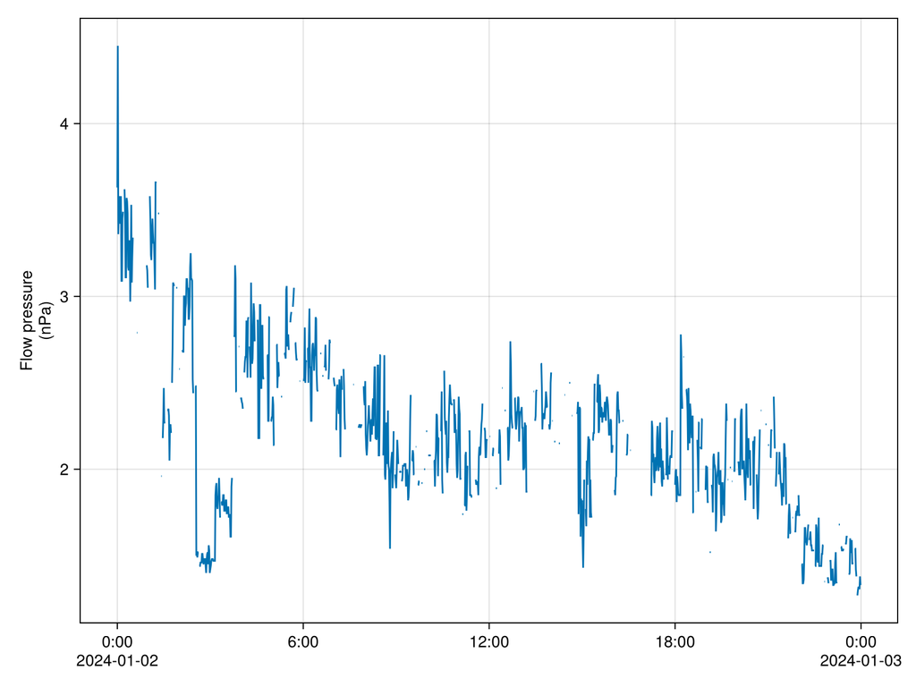

```julia
tplot(data2)
```

## Get data using Heliophysics Application Programmer’s Interface (HAPI)

HAPIClient.jl provides functions to load data from HAPI-compliant servers.

It could be installed at REPL via `using Pkg; Pkg.add("HAPIClient")`.

```julia
import HAPIClient

vars = HAPIClient.get_data("CDAWeb/AC_H0_MFI/Magnitude,BGSEc", t0, t1)
```

```
HAPIVariables: CDAWeb/AC_H0_MFI (https://cdaweb.gsfc.nasa.gov/hapi/data?parameters=Magnitude%2CBGSEc&id=AC_H0_MFI&time.max=2024-01-03T00%3A00%3A00.000Z&format=csv&time.min=2024-01-02T00%3A00%3A00.000Z)
  Magnitude [Time Range: 2024-01-02T00:00:12 to 2024-01-02T23:59:56, Units: nT, Size: (5400,)]
  BGSEc [Time Range: 2024-01-02T00:00:12 to 2024-01-02T23:59:56, Units: nT, Size: (5400, 3)]
Metadata - SpaceDataModel.NoMetadata()
```

### Plot the data

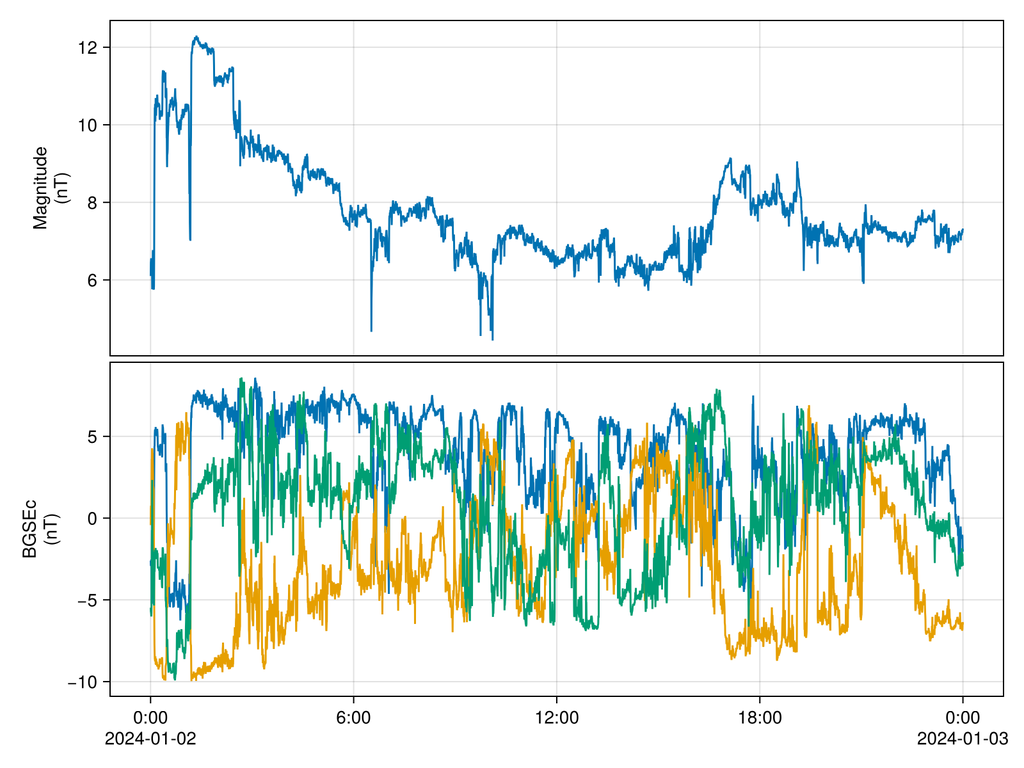

```julia
tplot(vars)
```

## Get data with `PySPEDAS`

PySPEDAS.jl provides a Julia interface to the [PySPEDAS](https://github.com/spedas/pyspedas) Python package, offering a similar API for Julia users to utilize the existing Python routines.

It could be installed at REPL via `using Pkg; Pkg.add("PySPEDAS")`.

```julia
using PySPEDAS.Projects

# Same as more verbose `pyspedas.projects.themis.fgm(...)`
tvars = themis.fgm([t0, t1], time_clip=true, probe="d");
```

```
Precompiling PySPEDAS...
  1 dependency successfully precompiled in 1 seconds. 89 already precompiled.
24-Oct-26 09:50:08: File is current: /Users/zijin/data/themis/thd/l2/fgm/2024/thd_l2_fgm_20240102_v01.cdf
```

### Plot the data

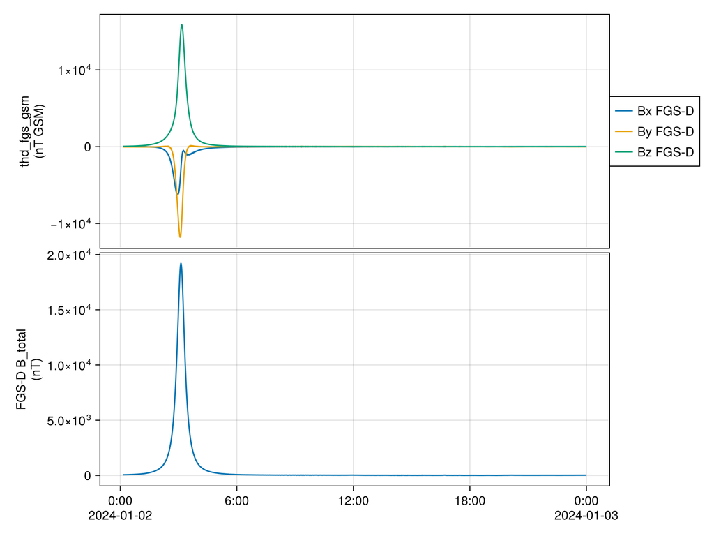

```julia
tplot((tvars.thd_fgs_gsm, tvars.thd_fgs_btotal))
```

## Composite plot

Combine all the data into a single plot with multiple panels.

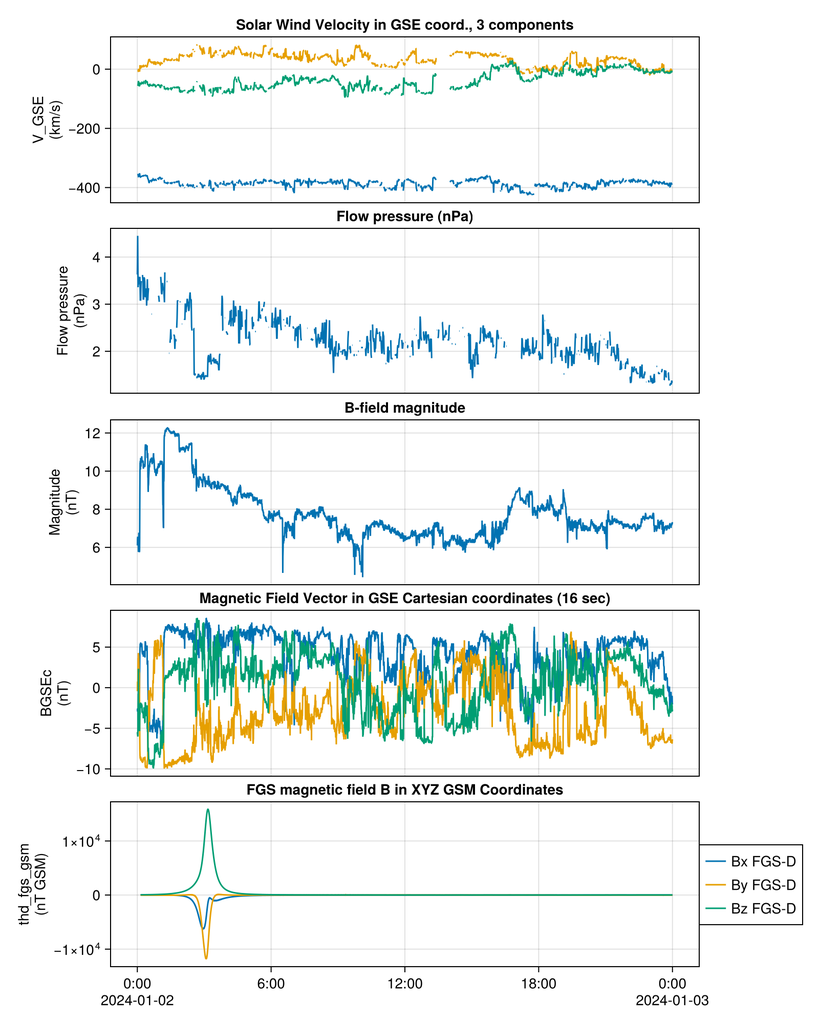

```julia
tplot((data1, data2, vars..., tvars.thd_fgs_gsm), add_title=true)
```

## Reproducibility

**NoteThis tutorial was built using these direct dependencies**

```julia
using Pkg
Pkg.status()
```

```
Status `~/src/JuliaSpacePhysics/juliaspacephysics.github.io/tutorials/data_loading/Project.toml`
  [950ff2a9] CDAWeb v0.3.3
  [13f3f980] CairoMakie v0.15.16
  [0ce0b37c] HAPIClient v0.3.3
  [668d2cef] PySPEDAS v0.3.3
  [0c28ffd8] SpacePhysicsMakie v0.4.2
  [09b745ad] Speasy v0.6.2
```

**NoteMachine and Julia version information**

```julia
using InteractiveUtils # hide
versioninfo()
```

```
Julia Version 1.14.0-alpha1
Build Info:
  Official https://julialang.org release
  Commit 30593bd2a76 (2026-10-20 06:21 UTC)
  GC: Built with stock GC
Platform Info:
  OS: macOS (arm64-apple-darwin25.6.0)
  CPU: 10 × Apple M5 (apple-m5)
  WORD_SIZE: 64
  LLVM: libLLVM-23.1.4 (ORCJIT, apple-m5)
Threads: 1 default, 1 interactive, 1 GC (on 10 virtual cores)
Environment:
  JULIA_LOAD_PATH = @:@stdlib
  JULIA_MAX_NUM_PRECOMPILE_FILES = 3
  JULIA_APPS_JULIA_CMD = julia
  JULIA_PROJECT = @.
```

Back to top